# 204.2. The Monster reference catalog

For the Rubin Science Platform at data.lsst.cloud.  
Data Release: [Data Preview 2](https://dp2.lsst.io/)  
Container Size: Large  
LSST Science Pipelines version: r30.0.10  
Last verified to run: 2026-07-23  
Repository: github.com/lsst/tutorial-notebooks  
DOI: 10.11578/rubin/dc.20250909.20

**Learning objective:** To learn about "The Monster" reference catalog.

**LSST data products:** `the_monster`, `Visit` table, `Source` table.

**Packages:** `numpy`, `matplotlib`, `astropy`, `lsst.geom`, `lsst.daf.butler`, `lsst.meas.algorithms`, `lsst.rsp`.

**Credit:** Originally developed by the Rubin Community Science team. Please consider acknowledging them if this notebook is used for the preparation of journal articles, software releases, or other notebooks.

**Get Support:** Everyone is encouraged to ask questions or raise issues in the [Support Category](https://community.lsst.org/c/support) of the Rubin Community Forum. Rubin staff will respond to all questions posted there.

## 1. Introduction

To support the photometric and astrometric calibration of data from the Vera C. Rubin Observatory, an all-sky reference catalog called *The Monster* has been developed. This catalog provides synthetic fluxes in the LSST **ugrizy** bandpasses, constructed by combining and transforming data from a prioritized list of external reference catalogs.

*The Monster* is designed to meet the demanding calibration requirements of the LSST, ensuring high source density ($>$10 reference stars per `NSIDE`=256 HEALPix pixel) and full-sky coverage for all bands. It includes astrometry based on [Gaia DR3](https://ui.adsabs.harvard.edu/abs/2023A&A...674A...1G/abstract), and photometry transformed into LSST-native bandpasses, minimizing the need for additional color transformations during image processing.

**References**:

- [DMTN-277: The Monster: A reference catalog with synthetic ugrizy-band fluxes for the Vera C. Rubin observatory](https://dmtn-277.lsst.io/)
- The DP2 schema browser: sdm-schemas.lsst.io/lsstcam.html

**Related tutorials:** The DP2 tutorial on astrometric calibration uses *The Monster* as the astrometric reference, and also demonstrates the new proper-motion and parallax catalogs.

### 1.1. Import packages

Import `numpy`, a fundamental package for scientific computing with arrays in Python (numpy.org), and `matplotlib`, a comprehensive library for data visualization ([matplotlib.org](https://matplotlib.org/)).

From `astropy`, import modules for celestial coordinate transformations, units, and time handling ([astropy.org](https://www.astropy.org/)).

From the `lsst` package, import the Butler and geometry utilities, the `ReferenceObjectLoader` (which retrieves *The Monster* while accounting for proper motions), and the `RSPDiscovery` class for accessing the RSP TAP service. ([pipelines.lsst.io](https://pipelines.lsst.io/)).

```python
import numpy as np
import matplotlib.pyplot as plt
from astropy.coordinates import SkyCoord
import astropy.units as u
from astropy.time import Time

import lsst.geom
from lsst.daf.butler import Butler
from lsst.rsp import RSPDiscovery
from lsst.meas.algorithms import ReferenceObjectLoader
from lsst.rsp import get_tap_service
```

### 1.2. Define parameters and functions

Instantiate the Butler with the DP2 repository and collection.

```python
butler = Butler("dp2", collections=["dp2"])
```

Instantiate `RSPDiscovery` with the `DP2` release, create an instance of the TAP service, and assert that it exists

```python
discovery = RSPDiscovery("dp2")
service = discovery.get_tap_client()
```

## 2. Access

Define a target sky position (in degrees) and a band. Use a location near the center of the Extended Chandra Deep Field South (ECDFS).

```python
ra_cen, dec_cen = 53.076, -28.110
my_band = 'i'
```

Find the visits whose footprint overlaps the target position, using the Butler's `visit` dimension records. This queries only visit metadata in the registry (no images or catalogs are loaded) and is the recommended way to identify visits by sky position. Take one overlapping visit in the chosen band.

```python
visit_records = butler.query_dimension_records(
    "visit",
    where="band.name = :band AND visit.region OVERLAPS POINT(:ra, :dec)",
    bind={"band": my_band, "ra": ra_cen, "dec": dec_cen})
visit_ids = sorted(rec.id for rec in visit_records)
print(f"Number of {my_band}-band visits overlapping the target: {len(visit_ids)}")
visit_id = visit_ids[20]
print("Using visit:", visit_id)
```

```
Number of i-band visits overlapping the target: 100
Using visit: 2025072100533
```

Query the `Visit` table with the TAP service to get this visit's exposure midpoint. The `expMidpt` column is the exposure midpoint as a timestamp (TAI), and `expMidptMJD` is the same quantity as a Modified Julian Date, which is convenient for building an `astropy` `Time`. See the [DP2 schema](https://sdm-schemas.lsst.io/lsstcam.html#Visit).

```python
query = (
    "SELECT visit, expMidpt, expMidptMJD "
    "FROM dp2.Visit "
    f"WHERE visit = {visit_id}"
)
job = service.submit_job(query)
job.run()
job.wait(phases=['COMPLETED', 'ERROR'])
print('Job phase is', job.phase)
if job.phase == 'ERROR':
    job.raise_if_error()
assert job.phase == 'COMPLETED'
visit_info = job.fetch_result().to_table()
```

```
Job phase is COMPLETED
```

Build the epoch from the exposure midpoint.

```python
epoch = Time(float(visit_info['expMidptMJD'][0]), format='mjd', scale='tai')
print("Exposure midpoint:", visit_info['expMidpt'][0], "| epoch (MJD):", epoch.mjd)
```

```
Exposure midpoint: 2025-07-22T07:23:21.681 | epoch (MJD): 60878.30788983057
```

Get the tract corresponding to the field center, using the skymap.

```python
my_spherePoint = lsst.geom.SpherePoint(ra_cen*lsst.geom.degrees,
                                       dec_cen*lsst.geom.degrees)
skymap = butler.get('skyMap', skymap='lsst_cells_v2')
tract = skymap.findTract(my_spherePoint)
my_tract = tract.tract_id
print('my_tract: ', my_tract)
```

```
my_tract:  5063
```

Find the name of *The Monster* catalog in the registry. The catalog is versioned by date, so the exact dataset type name may differ between data releases.

```python
monster_dataset_types = sorted(
    dt.name for dt in butler.registry.queryDatasetTypes("*monster*")
    if dt.name.startswith("the_monster"))
monster_dataset_types
```

```
['the_monster_20250219']
```

Use the most recent version of the catalog.

```python
monster_name = monster_dataset_types[-1]
print(monster_name)
```

```
the_monster_20250219
```

Get the reference datasets for the tract above.

```python
monsterRefs = butler.registry.queryDatasets(monster_name,
                                            tract=my_tract,
                                            skymap='lsst_cells_v2').expanded()
```

Get the data IDs containing all the `htm7` IDs and the reference catalogs for each `htm7` in this tract.

```python
data_ids = [ref.dataId for ref in monsterRefs]
refCats = [butler.getDeferred(ref) for ref in monsterRefs]
```

Define a `ReferenceObjectLoader` object for *The Monster* catalog. This enables proper motions to be taken into account relative to Gaia's reference epoch, `J2016.0`.

```python
monsterLoader = ReferenceObjectLoader(dataIds=data_ids, refCats=refCats)
```

> **Warning**: It is also possible to retrieve *The Monster* catalog via `butler.get`, but it is recommended to use `ReferenceObjectLoader` instead to take into account proper motions.

Define a radius around the central point, and get *The Monster*, corrected to the visit's exposure epoch.

```python
radius = 0.5
monster = monsterLoader.loadSkyCircle(my_spherePoint,
                                      radius*lsst.geom.degrees,
                                      'phot_g_mean',
                                      epoch=epoch).refCat.asAstropy()
```

```
lsst.meas.algorithms.loadReferenceObjects.ReferenceObjectLoader INFO: Loading reference objects from None in region bounded by [52.50913041, 53.64286959], [-28.61000172, -27.60999828] RA Dec
```

```
lsst.meas.algorithms.loadReferenceObjects.ReferenceObjectLoader INFO: Loaded 2812 reference objects
```

```
lsst.meas.algorithms.loadReferenceObjects.ReferenceObjectLoader INFO: Correcting reference catalog for proper motion to <Time object: scale='tai' format='mjd' value=60878.30788983057>
```

> **Note**: the argument `phot_g_mean` is needed for the call to succeed, but is not relevant in this case.

Filter out `NaN`s.

```python
monster = monster[np.isfinite(monster['coord_ra'])]
```

### 2.1. Schema

Use the catalog above to check the schema.

As noted in [DMTN-277](https://dmtn-277.lsst.io), for each photometric system and bandpass included in *The Monster*, there are three associated columns:

- `monster_{system}_{band}_flux`: estimated flux in the given band of the specified system.
- `monster_{system}_{band}_fluxErr`: uncertainty on the flux estimate.
- `monster_{system}_{band}_source_flag`: flag denoting which catalog was the source of the flux measurement.

In addition to the photometric data, *The Monster* includes astrometric and photometric measurements from **Gaia DR3** for all entries: positions and their uncertainties, proper motions, parallaxes, G, BP, and RP fluxes, and astrometric flags and covariances.

```python
monster.colnames
```

```
['id',
 'coord_ra',
 'coord_dec',
 'phot_g_mean_flux',
 'phot_bp_mean_flux',
 'phot_rp_mean_flux',
 'phot_g_mean_fluxErr',
 'phot_bp_mean_fluxErr',
 'phot_rp_mean_fluxErr',
 'coord_raErr',
 'coord_decErr',
 'epoch',
 'pm_ra',
 'pm_dec',
 'pm_raErr',
 'pm_decErr',
 'pm_flag',
 'parallax',
 'parallaxErr',
 'parallax_flag',
 'coord_ra_coord_dec_Cov',
 'coord_ra_pm_ra_Cov',
 'coord_ra_pm_dec_Cov',
 'coord_ra_parallax_Cov',
 'coord_dec_pm_ra_Cov',
 'coord_dec_pm_dec_Cov',
 'coord_dec_parallax_Cov',
 'pm_ra_pm_dec_Cov',
 'pm_ra_parallax_Cov',
 'pm_dec_parallax_Cov',
 'astrometric_excess_noise',
 'monster_ComCam_g_flux',
 'monster_ComCam_g_fluxErr',
 'monster_ComCam_g_source_flag',
 'monster_ComCam_i_flux',
 'monster_ComCam_i_fluxErr',
 'monster_ComCam_i_source_flag',
 'monster_ComCam_r_flux',
 'monster_ComCam_r_fluxErr',
 'monster_ComCam_r_source_flag',
```

[output cut: 27 more lines]

```
 'monster_LATISS_r_flux',
 'monster_LATISS_r_fluxErr',
 'monster_LATISS_r_source_flag',
 'monster_LATISS_y_flux',
 'monster_LATISS_y_fluxErr',
 'monster_LATISS_y_source_flag',
 'monster_LATISS_z_flux',
 'monster_LATISS_z_fluxErr',
 'monster_LATISS_z_source_flag',
 'monster_ComCam_u_flux',
 'monster_ComCam_u_fluxErr',
 'monster_ComCam_u_source_flag',
 'monster_SDSS_u_flux',
 'monster_SDSS_u_fluxErr',
 'monster_SDSS_u_source_flag']
```

## 3. Cross match objects with *The Monster*

Extract *The Monster* stars' coordinates as arrays `coord_ra` and `coord_dec`.

```python
coord_ra = monster['coord_ra']
coord_dec = monster['coord_dec']
```

Check one of the columns to verify that the coordinates are in radians.

```python
coord_ra
```

<Column name='coord_ra' dtype='float64' unit='rad' description='position in ra/dec' length=2121>

| 0.9172279796470385 |
| --- |
| 0.9172857206573967 |
| 0.917241358157227 |
| 0.9173895268502462 |
| 0.9176169625797136 |
| 0.9172450725212975 |
| 0.9178700348322678 |
| 0.91777750572389 |
| 0.917806818245459 |
| 0.917429726764242 |
| 0.9176133822472147 |
| 0.9173647278506093 |
| 0.9174534335428495 |
| 0.9175710789646457 |
| 0.9176253412974905 |
| 0.9175708928458335 |
| 0.9180833755090329 |
| 0.9167052150014452 |
| 0.9170157621921692 |
| 0.9167874300739216 |
| 0.9173239225455009 |
| 0.91730707827123 |
| 0.9178298071981559 |
| 0.9170945497381964 |
| 0.9169522608335602 |
| 0.916899718387485 |
| 0.9173048952632232 |
| ... |
| 0.9329637610140844 |
| 0.933579361919568 |
| 0.9319276522625346 |
| 0.9316923559555184 |
| 0.9315894398093628 |
| 0.93162899680871 |
| 0.9317768201814454 |
| 0.9326515102349993 |
| 0.9326789691436769 |
| 0.9329732779801092 |
| 0.9322004145250246 |
| 0.9321306914150354 |
| 0.9327271292123137 |
| 0.9345179627332703 |
| 0.9340013892819302 |
| 0.9341197574321265 |
| 0.9343717431462082 |
| 0.9342950542962819 |
| 0.9335529848286463 |
| 0.9340510305366722 |
| 0.9308985531768568 |
| 0.9309765564942306 |
| 0.9317373774440136 |
| 0.9314178592066111 |
| 0.9314242987554479 |
| 0.9305509596957661 |
| 0.9318240809893591 |

Retrieve the observed stars used for Point Spread Function (PSF) modeling in this visit, from the `Source` table via the TAP service. Select only the stars flagged with `calib_psf_used`, within the field radius.

```python
query = (
    "SELECT ra, dec "
    "FROM dp2.Source "
    f"WHERE visit = {visit_id} "
    "AND calib_psf_used = 1 "
    "AND CONTAINS(POINT('ICRS', ra, dec), "
    f"CIRCLE('ICRS', {ra_cen}, {dec_cen}, {radius})) = 1"
)
job = service.submit_job(query)
job.run()
job.wait(phases=['COMPLETED', 'ERROR'])
print('Job phase is', job.phase)
if job.phase == 'ERROR':
    job.raise_if_error()
assert job.phase == 'COMPLETED'
source_table = job.fetch_result().to_table()
```

```
Job phase is COMPLETED
```

```python
source_ra = np.asarray(source_table['ra'])
source_dec = np.asarray(source_table['dec'])
print(len(source_ra))
```

```
1146
```

Crossmatch Gaia stars from *The Monster* with the stars used for PSF modeling. First, build `SkyCoord` objects (note that *The Monster* coordinates are in radians, and the `Source` coordinates are in degrees).

```python
source_coords = SkyCoord(ra=source_ra * u.deg, dec=source_dec * u.deg)
monster_coords = SkyCoord(ra=coord_ra.to(u.deg), dec=coord_dec.to(u.deg))
```

Match each source to the closest *Monster* star.

```python
idx, d2d, _ = source_coords.match_to_catalog_sky(monster_coords)
```

Filter matches within 1 arcsec.

```python
max_sep = 1.0
matched = d2d.arcsecond < max_sep
print(f"Matched {matched.sum()} out of {len(source_coords)} sources within {max_sep} arcsec.")
```

```
Matched 964 out of 1146 sources within 1.0 arcsec.
```

Visualize the matches.

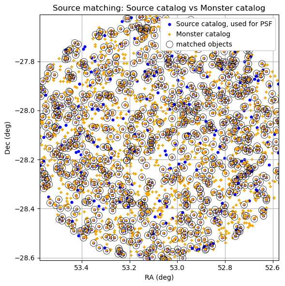

```python
plt.figure(figsize=(6, 6))
plt.scatter(source_ra, source_dec, s=12, color='blue', alpha=1.0,
            label='Source catalog, used for PSF')
plt.scatter(coord_ra.to(u.deg), coord_dec.to(u.deg), s=22, color='orange',
            marker='+', alpha=1.0, label='Monster catalog')
plt.plot(source_ra[matched], source_dec[matched], 'o', ms=10, mec='black', mew=0.5,
         color='None', label='matched objects')
plt.xlabel('RA (deg)')
plt.ylabel('Dec (deg)')
plt.xlim([ra_cen + radius, ra_cen - radius])
plt.ylim([dec_cen - radius, dec_cen + radius])
plt.title('Source matching: Source catalog vs Monster catalog')
plt.legend(loc='upper right', framealpha=1, handletextpad=0)
plt.grid(True)
plt.tight_layout()
plt.show()
```

> **Figure 1**: RA vs. Dec for the stars used to estimate the PSF in this visit (from the `Source` table; blue circles) and stars from *The Monster* reference catalog (orange crosses). Matches within 1 arcsec are circled.

### 3.1. Astrometric residuals

Calculate and visualize the residuals between the matched `Source` and *Monster* positions.

Compute residuals.

```python
residuals_ra = source_coords[matched].ra - monster_coords[idx][matched].ra
residuals_dec = source_coords[matched].dec - monster_coords[idx][matched].dec
```

Extract sky positions.

```python
ra = source_coords[matched].ra.deg
dec = source_coords[matched].dec.deg
```

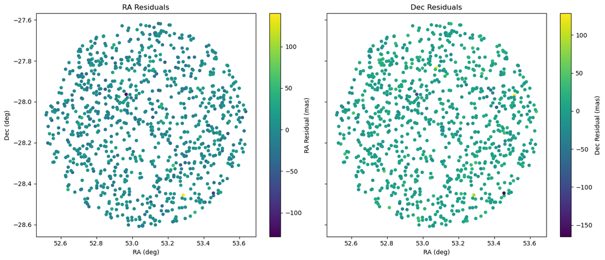

```python
fig, (ax1, ax2) = plt.subplots(1, 2, figsize=(14, 6),
                               sharex=True, sharey=True)

sc1 = ax1.scatter(ra, dec, c=residuals_ra.to('mas').value, s=20)
fig.colorbar(sc1, ax=ax1, label='RA Residual (mas)')
ax1.set_title("RA Residuals")
ax1.set_xlabel("RA (deg)")
ax1.set_ylabel("Dec (deg)")
ax1.invert_xaxis()

sc2 = ax2.scatter(ra, dec, c=residuals_dec.to('mas').value, s=20)
fig.colorbar(sc2, ax=ax2, label='Dec Residual (mas)')
ax2.set_title("Dec Residuals")
ax2.set_xlabel("RA (deg)")
ax2.invert_xaxis()

plt.tight_layout()
plt.show()
```

> **Figure 2:** Astrometric residuals in RA (left) and Dec (right), between the matched `Source` positions and *The Monster* reference positions.